# exploration_slide_deck_ slides

## Communicate Data Findings

### Intodaction

#### This project is divided into two major parts :

#### In the first part, we will conduct an exploratory data analysis on a dataset of prosperLoanData. We will use Python data science and data visualization libraries to explore the dataset’s variables and understand the data’s structure, oddities, patterns and relationships. The analysis in this part is structured, going from multivariate relationships.

#### In the second part, We will take our main findings from our exploration and convey them to others through an explanatory analysis. To this end, We will create a slide deck that leverages polished, explanatory visualizations to communicate your results.

## What is the structure of your dataset?

#### There are total of 113937 loans entries saved in the dataset and 81 attributes. Each loan contain information on the borrowered's background information and details regarding the loans.

#### This analysis will focus on factors that are related to Prosper loans status (LoanStatus).

#### The independent variables of interest are:

```
<class 'pandas.core.frame.DataFrame'>
RangeIndex: 113937 entries, 0 to 113936
Data columns (total 17 columns):
Term                         113937 non-null category
LoanStatus                   113937 non-null category
BorrowerRate                 113937 non-null float64
ProsperRating (Alpha)        84853 non-null object
ListingCategory (numeric)    113937 non-null int64
EmploymentStatus             111682 non-null category
DelinquenciesLast7Years      112947 non-null float64
StatedMonthlyIncome          113937 non-null float64
TotalProsperLoans            22085 non-null float64
LoanOriginalAmount           113937 non-null int64
LoanOriginationDate          113937 non-null object
Recommendations              113937 non-null int64
Investors                    113937 non-null int64
BorrowerAPR                  113912 non-null float64
ProsperScore                 84853 non-null category
Occupation                   110349 non-null object
IncomeRange                  113937 non-null category
dtypes: category(5), float64(5), int64(4), object(3)
memory usage: 11.0+ MB
None
```

## Exploration

#### The main thing I want to explore in this part of the analysis is how the categorical variable (Prosper rating and term) play into the relationship between borrower APR , loan original amount , monthely incom and employment status

## 1- Term effect on relationship of APR and loan amount

### Observation:

#### Term doesn't seem to have effect on relationship of APR and loan amount

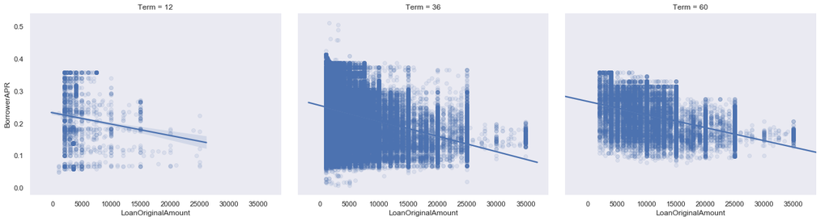

## 2- Prosper rating effect on relationship of APR and loan amount

### Observation:

#### 1- The loan amount increases with better rating.

#### 2- The borrower APR decreases with better rating.

#### 3- Interestingly, the relationship between borrower APR and loan amount turns from negative to slightly positive when the Prosper ratings are increased from HR to A or better. This may because people with A or AA ratings tend to borrow more money, increasting APR could prevent them borrow even more and maximize the profit. But people with lower ratings tend to borrow less money, decreasing APR could encourage them to borrow more.

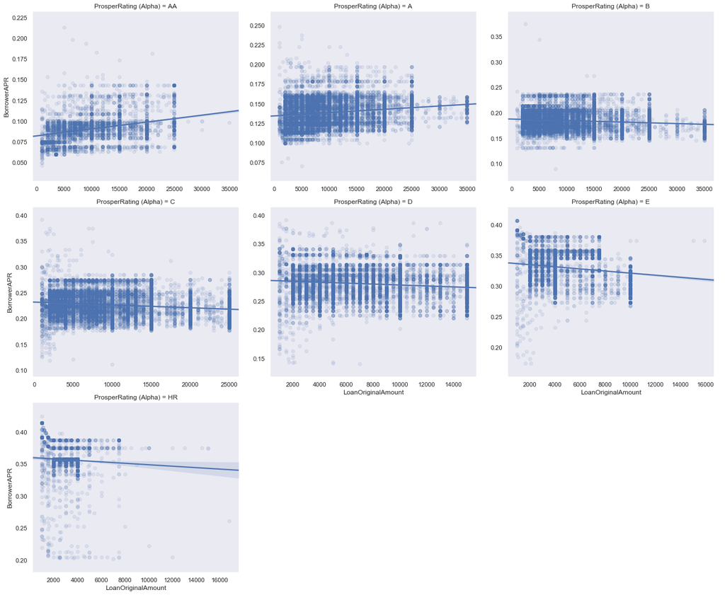

## 3- Borrower APR across Prosper rating and term

### Observation:

#### Interestingly, the borrower APR decrease with the increase of borrow term for people with HR-C raings. But for people with B-AA ratings, the APR increase with the increase of borrow term.

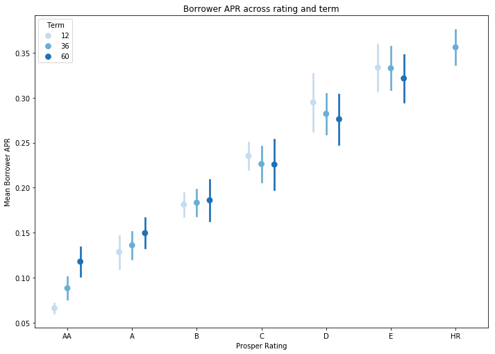

## 4- The Prosper rating and term effects on stated monthly income and loan original amount

### Observation:

#### 1- For stated monthly income, it doesn't seem like there is a interaction effect between term and rating, the pattern of term is similar among different ratings.

#### 2- But for loan amount, there is a interaction between term and rating.

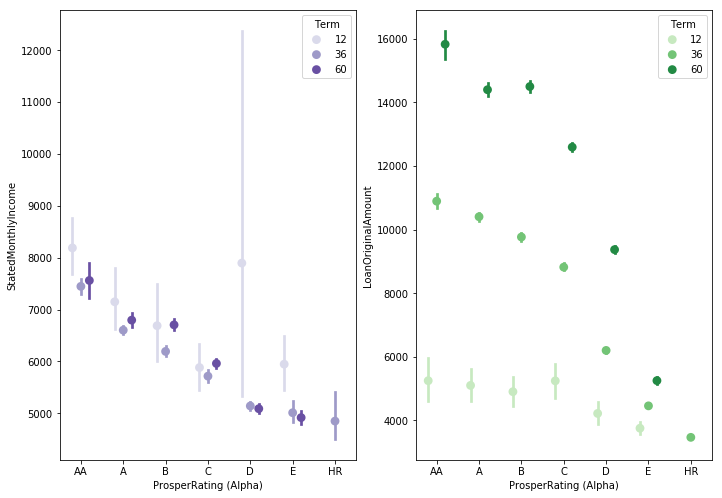

### Continue the observations:

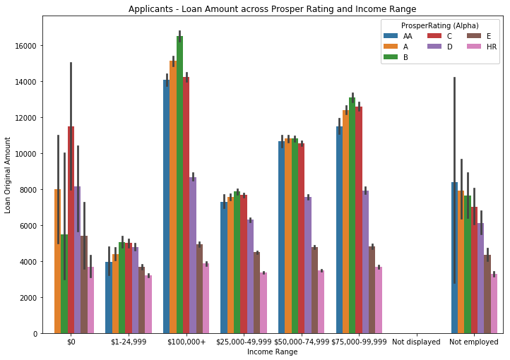

## 5- Does rating depend on the monhtly income and Employment status?

### Observation:

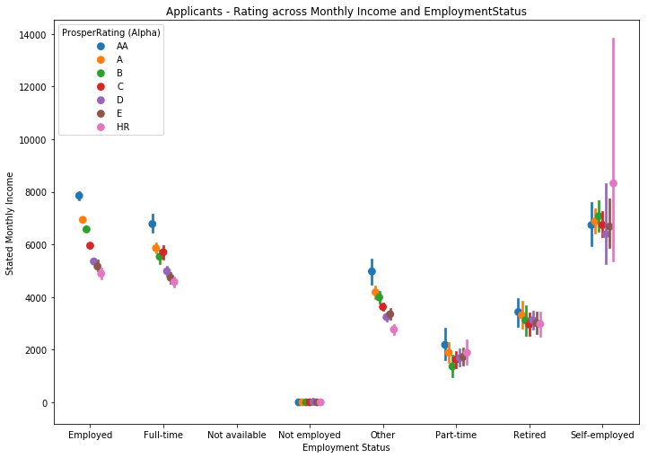

### Insights from the multivariate exploration data

1- For Applicants with prosper ratings from AA to D have the higher loan amount with increased salary

2- Employed and full time employees have their mean salaries in higher range

5- HR prosper rating applicants have higher interest rates